# Customer Churn Analysis Project

# 4. Feature Engineering

```r
# Convert categorical to factors
churn <- churn %>%
  mutate_if(is.character, as.factor)

# Create tenure bucket
churn <- churn %>%
  mutate(tenure_group = cut(tenure, breaks = c(0, 12, 24, 48, 60, Inf),
                            labels = c("0-12", "13-24", "25-48", "49-60", "60+")))

# Drop customerID
churn$customer_id <- NULL
```

This step involves transforming and preparing the existing variables in a way that ensures the predictive power of the model. Many of the variables in the data are categorical and need to be converted into factors so they can be properly interpreted by modeling algorithms in R in the following steps. Additionally, creating new features such as tenure groups helps to capture nonlinear patterns in customer behavior. Feature engineering is an important step that improves model accuracy, interpretability, and compatibility with different types of algorithms used later in the analysis.

# 5. Model Building

## Logistic Regression

```r
# Train/test split
set.seed(123)
train_idx <- createDataPartition(churn$churn, p = 0.8, list = FALSE)
train <- churn[train_idx, ]
test <- churn[-train_idx, ]

# Logistic Regression
log_model <- glm(churn ~ ., data = train, family = binomial)
summary(log_model)
```

```
##
## Call:
## glm(formula = churn ~ ., family = binomial, data = train)
##
## Coefficients: (7 not defined because of singularities)
##                                         Estimate Std. Error z value Pr(>|z|)
## (Intercept)                            1.649e+00  9.081e-01   1.816  0.06932
## genderMale                            -3.288e-02  7.284e-02  -0.451  0.65167
## senior_citizen                         2.708e-01  9.455e-02   2.864  0.00418
## partnerYes                            -2.828e-02  8.742e-02  -0.324  0.74631
## dependentsYes                         -7.566e-02  1.012e-01  -0.747  0.45492
## tenure                                -6.832e-02  1.066e-02  -6.410 1.45e-10
## phone_serviceYes                       4.804e-01  7.219e-01   0.666  0.50573
## multiple_linesNo phone service                NA         NA      NA       NA
## multiple_linesYes                      5.238e-01  1.973e-01   2.655  0.00793
## internet_serviceFiber optic            2.189e+00  8.893e-01   2.461  0.01385
## internet_serviceNo                    -2.141e+00  8.977e-01  -2.385  0.01707
## online_securityNo internet service            NA         NA      NA       NA
## online_securityYes                    -9.524e-02  1.983e-01  -0.480  0.63106
## online_backupNo internet service              NA         NA      NA       NA
## online_backupYes                       1.134e-01  1.958e-01   0.579  0.56251
## device_protectionNo internet service          NA         NA      NA       NA
## device_protectionYes                   2.838e-01  1.965e-01   1.444  0.14872
## tech_supportNo internet service               NA         NA      NA       NA
## tech_supportYes                       -3.687e-02  2.014e-01  -0.183  0.85474
## streaming_tvNo internet service               NA         NA      NA       NA
## streaming_tvYes                        8.065e-01  3.629e-01   2.223  0.02624
## streaming_moviesNo internet service           NA         NA      NA       NA
## streaming_moviesYes                    8.492e-01  3.643e-01   2.331  0.01976
## contractOne year                      -7.043e-01  1.211e-01  -5.818 5.95e-09
## contractTwo year                      -1.540e+00  2.050e-01  -7.516 5.65e-14
## paperless_billingYes                   3.543e-01  8.372e-02   4.231 2.32e-05
## payment_methodCredit card (automatic)  1.180e-03  1.266e-01   0.009  0.99256
## payment_methodElectronic check         2.518e-01  1.055e-01   2.387  0.01699
## payment_methodMailed check            -1.638e-01  1.288e-01  -1.272  0.20328
## monthly_charges                       -5.576e-02  3.537e-02  -1.577  0.11491
## total_charges                          2.065e-04  8.414e-05   2.454  0.01411
## tenure_group13-24                     -1.852e-01  1.533e-01  -1.208  0.22686
## tenure_group25-48                      2.522e-01  2.689e-01   0.938  0.34833
## tenure_group49-60                      9.418e-01  4.316e-01   2.182  0.02909
```

[output cut: 32 more lines]

```
## total_charges                         *
## tenure_group13-24
## tenure_group25-48
## tenure_group49-60                     *
## tenure_group60+                       *
## ---
## Signif. codes:  0 '***' 0.001 '**' 0.01 '*' 0.05 '.' 0.1 ' ' 1
##
## (Dispersion parameter for binomial family taken to be 1)
##
##     Null deviance: 6517.2  on 5626  degrees of freedom
## Residual deviance: 4635.6  on 5599  degrees of freedom
## AIC: 4691.6
##
## Number of Fisher Scoring iterations: 6
```

```r
# Predict & evaluate
log_probs <- predict(log_model, test, type = "response")
log_pred <- ifelse(log_probs > 0.5, "Yes", "No") %>% factor(levels = c("No", "Yes"))

confusionMatrix(log_pred, test$churn)
```

```
## Confusion Matrix and Statistics
##
##           Reference
## Prediction  No Yes
##        No  932 166
##        Yes 100 207
##
##                Accuracy : 0.8107
##                  95% CI : (0.7892, 0.8309)
##     No Information Rate : 0.7345
##     P-Value [Acc > NIR] : 1.364e-11
##
##                   Kappa : 0.4855
##
##  Mcnemar's Test P-Value : 6.736e-05
##
##             Sensitivity : 0.9031
##             Specificity : 0.5550
##          Pos Pred Value : 0.8488
##          Neg Pred Value : 0.6743
##              Prevalence : 0.7345
##          Detection Rate : 0.6633
##    Detection Prevalence : 0.7815
##       Balanced Accuracy : 0.7290
##
##        'Positive' Class : No
##
```

```r
# ROC AUC
roc_obj <- roc(test$churn, log_probs)
auc(roc_obj)
```

```
## Area under the curve: 0.8469
```

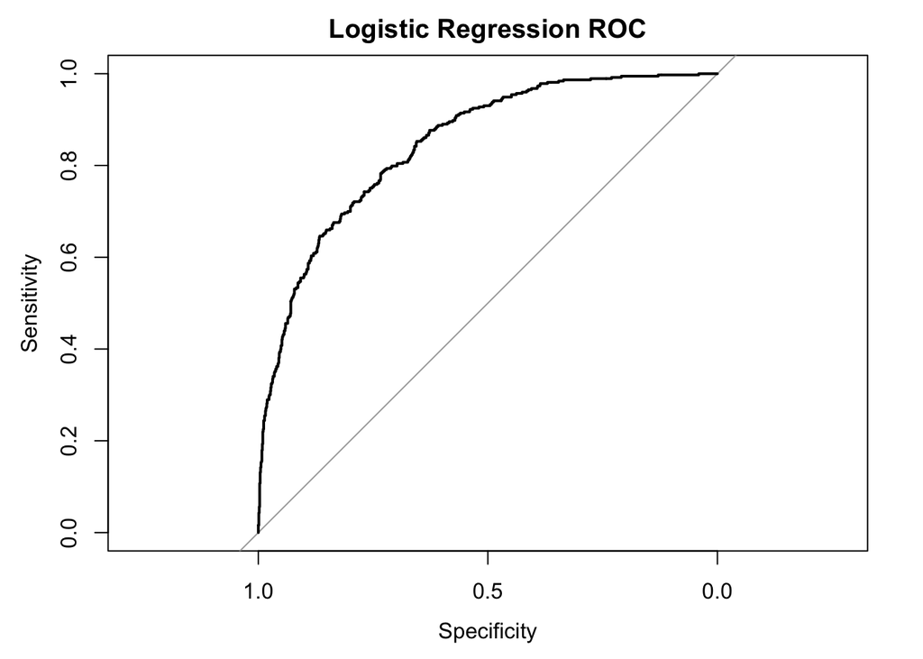

```r
plot(roc_obj, main = "Logistic Regression ROC")
```

The area under the ROC curve (AUC) is 0.8469 which suggests the model has strong discriminating power overall. The positive predictive value (precision for non-churn) is 0.8488 while the negative predictive value (for churn) is 0.6743. These values combined with a balanced accuracy of 0.729 demonstrate the model performs well at distinguishing between churn and non-churn cases but could benefit from further tuning or more advanced techniques to improve specificity.

## Random Forest

```r
rf_model <- randomForest(churn ~ ., data = train, ntree = 500, importance = TRUE)
rf_pred <- predict(rf_model, test)

confusionMatrix(rf_pred, test$churn)
```

```
## Confusion Matrix and Statistics
##
##           Reference
## Prediction  No Yes
##        No  930 179
##        Yes 102 194
##
##                Accuracy : 0.8
##                  95% CI : (0.7781, 0.8206)
##     No Information Rate : 0.7345
##     P-Value [Acc > NIR] : 6.374e-09
##
##                   Kappa : 0.451
##
##  Mcnemar's Test P-Value : 5.794e-06
##
##             Sensitivity : 0.9012
##             Specificity : 0.5201
##          Pos Pred Value : 0.8386
##          Neg Pred Value : 0.6554
##              Prevalence : 0.7345
##          Detection Rate : 0.6619
##    Detection Prevalence : 0.7893
##       Balanced Accuracy : 0.7106
##
##        'Positive' Class : No
##
```

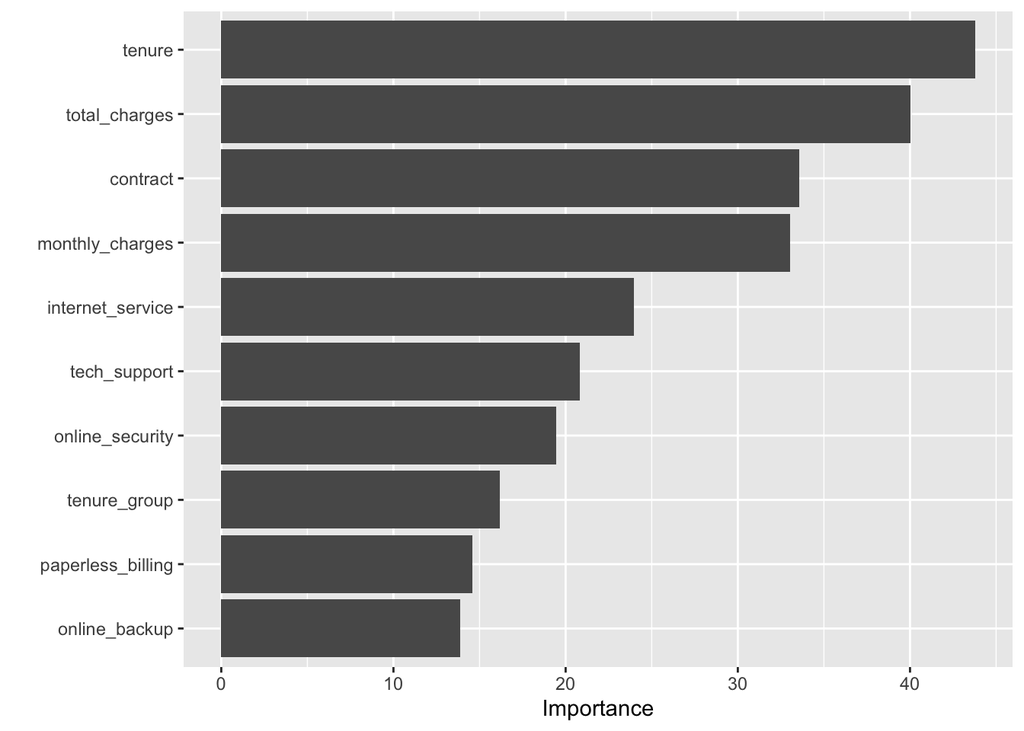

```r
# Variable importance
vip::vip(rf_model)
```

The variable importance plot reveals the most influential features in predicting churn. The plot underlines both customer longevity and billing structure are key drivers of retention. Additionally, service-related variables such as internet_service and tech_support also plays a substantial role. This indicates that the type and quality of services subscribed to may impact a customer’s decision to stay. These findings can inform targeted retention strategies, particularly for customers with short tenure, high charges, and flexible contracts.